# Beispielanalyse zum Prognose-Wettbewerb

Sebastian Sauer

Sie können sich an Ablauf und Aufbau dieser beispielhaften Analyse zur Prüfungsleistung Prognosewettbewerb orientieren. Auch andere Vorgehensweisen sind möglich. Beachten Sie, dass die dargestellte Vorgehensweise eine einfache, grundlegende Analyse darstellt, die keineswegs eine optimale Lösung vermittelt. Beachten Sie auch, dass pro Abschnitt eine Erläuterung, die Ihnen helfen soll dargestellt ist, übernehmen Sie nicht diese Inhalte, sondern setzen Sie die dargestellen Erläuterungen um. Wenn Sie nach Beispielen suchen, empfiehlt es sich, einschlägige Fallstudien durchzuarbeiten.

# 1 Beschreibung der Aufgabe

Im Datensatz `tips` soll die Zielvariable `tip` im *Test*-Datensatz vorhergesagt werden. Dazu können alle übrigen Variablen im Trainings-Datensatz als Prädiktoren herangezogen werden.

Die Forschungsfrage lautet also: “Wie gut kann man die Variable `tip` in diesem Datensatz vorhersagen? Welche Prädiktoren helfen dazu?”

In Ihrer Prüfungsleistung wird ein anderer Datensatz verwendet; das Beispiel mit dem Datensatz `tips` illustriert einige wesentliche Aspekte der Analyse.

Informationen (“Codebook”) zum Datensatz `tips` finden Sie [hier](https://vincentarelbundock.github.io/Rdatasets/doc/reshape2/tips.html).

# 2 Vorbereitung

## 2.1 Pakete laden

```r
library(tidyverse)
library(corrr)  # Korrelationen
```

## 2.2 Daten importieren

Den Train-Datensatz haben Sie vorliegen; dort sind X- und Y-Variablen bekannt. Den Test-Datensatz nutzen Sie, um die Zielvariable (Y) vorherzusagen. Die “Lösung” – die vorherzusagenden Y-Werte – sind nur der Lehrperson bekannt.

```r
tips_train <- read_csv("https://raw.githubusercontent.com/sebastiansauer/2021-sose/master/data/tips/tips_train.csv")
tips_test <- read_csv("https://raw.githubusercontent.com/sebastiansauer/2021-sose/master/data/tips/tips_test.csv")
```

*Ihr* Skript sollte zu Beginn den Datensatz *Ihrer* Prüfungsleistung importieren. Dieser Datensatz soll von der vom Dozenten ausgewiesenen Webseite bezogen werden. Lokal gespeicherte Datensätze dürfen (aus Gründen der Nachprüfgbarkeit der Ergebnisse) nicht verwendet werden.

# 3 Vorverarbeitung

Z.B. Analyse nach Extremwerten, Datentransformation etc.

## 3.1 Unbekannte Variable auf NA setzen

Das Trinkgeld (`tip`) ist vorherzusagen, daher unbekannt. Löschen wir also die Werte dieser Variablen. Die harte Wirklichkeit …

Zuerst ein Backup:

```r
tips_test_mit_Loesung <- tips_test
```

Dann das Löschen:

```r
tips_test$tip <- NA
```

Keine Sorge: Dieser Schritt wird von der Lehrperson erledigt. Sie bekommen schon den “richtigen” Test-Datensatz (wo die vorherzusagende Variable auf NA gesetzt ist).

## 3.2 Ein Blick in die Daten

Es bietet sich an, zu Beginn zu prüfen, ob die Daten korrekt importiert wurden.

```r
head(tips_train)
```

```
## # A tibble: 6 × 8
##      id total_bill   tip sex    smoker day   time    size
##   <dbl>      <dbl> <dbl> <chr>  <chr>  <chr> <chr>  <dbl>
## 1     1       17.0  1.01 Female No     Sun   Dinner     2
## 2     3       21.0  3.5  Male   No     Sun   Dinner     3
## 3     5       24.6  3.61 Female No     Sun   Dinner     4
## 4     8       26.9  3.12 Male   No     Sun   Dinner     4
## 5    11       10.3  1.71 Male   No     Sun   Dinner     2
## 6    12       35.3  5    Female No     Sun   Dinner     4
```

```r
head(tips_test)
```

```
## # A tibble: 6 × 8
##      id total_bill tip   sex   smoker day   time    size
##   <dbl>      <dbl> <lgl> <chr> <chr>  <chr> <chr>  <dbl>
## 1     2      10.3  NA    Male  No     Sun   Dinner     3
## 2     4      23.7  NA    Male  No     Sun   Dinner     2
## 3     6      25.3  NA    Male  No     Sun   Dinner     4
## 4     7       8.77 NA    Male  No     Sun   Dinner     2
## 5     9      15.0  NA    Male  No     Sun   Dinner     2
## 6    10      14.8  NA    Male  No     Sun   Dinner     2
```

## 3.3 Verteilung der Zielvariablwen

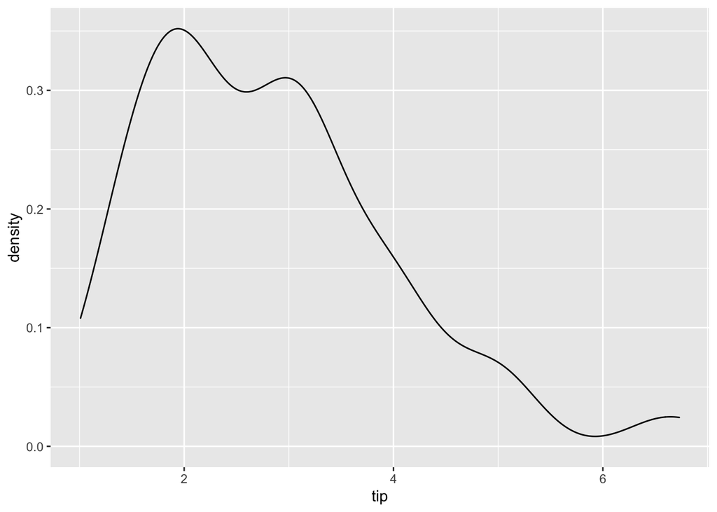

```r
ggplot(tips_train, aes(x = tip)) +
  geom_density()
```

Die Verteilung ist rechtsschief. Kann man durch eine Log-Transformation eine “normalere” Form erreichen?

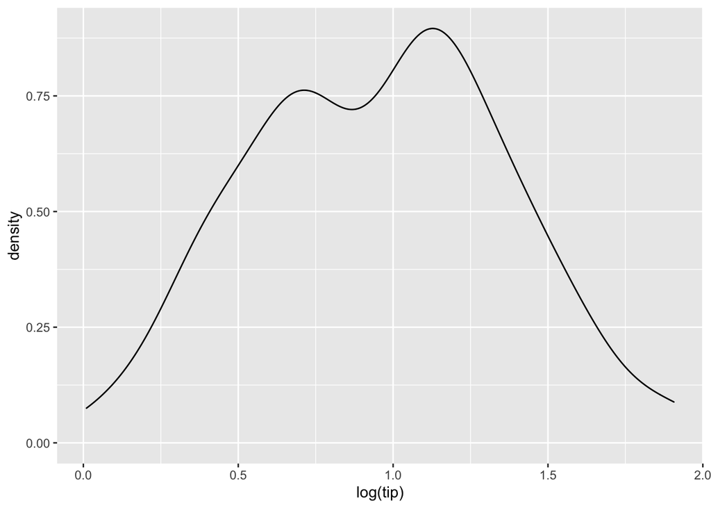

```r
ggplot(tips_train, aes(x = log(tip))) +
  geom_density()
```

Ja, sieht besser. Mit der log-transformierten Variablen könnten bessere Vorhersagen möglich sein.

Boxplots erlauben ebenfalls eine Visualisierung einer Verteilung einer Variablen:

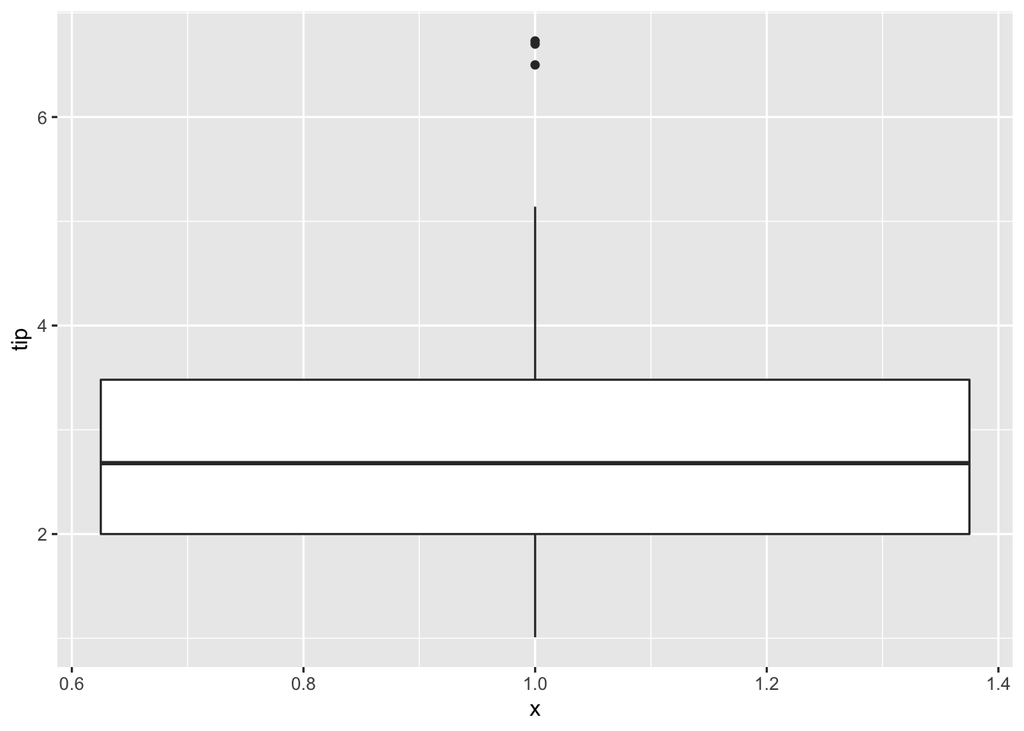

```r
ggplot(tips_train, aes(y = tip, x = 1)) +
  geom_boxplot()
```

## 3.4 Korrelationen der Prädiktoren mit der Zielvariablen

Das kann man so machen:

```r
tips_train %>%
  summarise(korr_tip_total_bill = cor(tip, total_bill))
```

```
## # A tibble: 1 × 1
##   korr_tip_total_bill
##                 <dbl>
## 1               0.670
```

… Ist aber auf Dauer umständlich, wenn man das für jede Variable machen möchte.

So geht es komfortabler:

```r
tips_train %>%
  select(where(is.numeric)) %>%
  correlate() %>%
  focus(tip)
```

```
##
## Correlation method: 'pearson'
## Missing treated using: 'pairwise.complete.obs'
```

```
## # A tibble: 3 × 2
##   term           tip
##   <chr>        <dbl>
## 1 id         -0.0162
## 2 total_bill  0.670
## 3 size        0.590
```

Die Variable `id` ist natürlich keine nützliche Variable, aber `total_bill` und `size` sind offenbar (oder möglicherweise) nützlich, um `tip` vorherzusagen, was wir aus der Korrelation erschließen.

# 4 Modellierung im Trainings-Datensatz (Phase 1)

## 4.1 Modell 1

```r
modell1 <- lm(tip ~ smoker, data = tips_train)
summary(modell1)
```

```
##
## Call:
## lm(formula = tip ~ smoker, data = tips_train)
##
## Residuals:
##     Min      1Q  Median      3Q     Max
## -1.8709 -0.9709 -0.0578  0.5674  3.9922
##
## Coefficients:
##             Estimate Std. Error t value Pr(>|t|)
## (Intercept)   2.7378     0.1357  20.173   <2e-16 ***
## smokerYes     0.2331     0.2210   1.055    0.294
## ---
## Signif. codes:  0 '***' 0.001 '**' 0.01 '*' 0.05 '.' 0.1 ' ' 1
##
## Residual standard error: 1.183 on 120 degrees of freedom
## Multiple R-squared:  0.009185,   Adjusted R-squared:  0.0009284
## F-statistic: 1.112 on 1 and 120 DF,  p-value: 0.2937
```

Hm, das $R^2$ ist noch nicht so gut…

## 4.2 Modell 2

```r
modell2 <- lm(tip ~ smoker + size, data = tips_train)
summary(modell2)
```

```
##
## Call:
## lm(formula = tip ~ smoker + size, data = tips_train)
##
## Residuals:
##     Min      1Q  Median      3Q     Max
## -1.9728 -0.7046 -0.1896  0.6688  2.9508
##
## Coefficients:
##             Estimate Std. Error t value Pr(>|t|)
## (Intercept)   0.7349     0.2610   2.816  0.00569 **
## smokerYes     0.4325     0.1772   2.441  0.01613 *
## size          0.7611     0.0903   8.429 9.42e-14 ***
## ---
## Signif. codes:  0 '***' 0.001 '**' 0.01 '*' 0.05 '.' 0.1 ' ' 1
##
## Residual standard error: 0.9401 on 119 degrees of freedom
## Multiple R-squared:  0.3796, Adjusted R-squared:  0.3692
## F-statistic:  36.4 on 2 and 119 DF,  p-value: 4.621e-13
```

Schon viel besser!

## 4.3 Modell 3

```r
modell3 <- lm(tip ~ smoker + size + sex, data = tips_train)
summary(modell3)
```

```
##
## Call:
## lm(formula = tip ~ smoker + size + sex, data = tips_train)
##
## Residuals:
##     Min      1Q  Median      3Q     Max
## -1.9570 -0.7286 -0.2061  0.6683  2.9823
##
## Coefficients:
##             Estimate Std. Error t value Pr(>|t|)
## (Intercept)  0.76475    0.26684   2.866  0.00493 **
## smokerYes    0.43850    0.17802   2.463  0.01521 *
## size         0.77078    0.09213   8.366 1.38e-13 ***
## sexMale     -0.10017    0.17530  -0.571  0.56880
## ---
## Signif. codes:  0 '***' 0.001 '**' 0.01 '*' 0.05 '.' 0.1 ' ' 1
##
## Residual standard error: 0.9428 on 118 degrees of freedom
## Multiple R-squared:  0.3813, Adjusted R-squared:  0.3656
## F-statistic: 24.24 on 3 and 118 DF,  p-value: 2.72e-12
```

Scheint nicht mehr besser zu werden ?!

Oder probieren wir doch noch ein anderes Modell …

## 4.4 Modell 4 - mit Log-Transformation

```r
modell4 <- lm(log(tip) ~ smoker + size + sex, data = tips_train)
summary(modell4)
```

```
##
## Call:
## lm(formula = log(tip) ~ smoker + size + sex, data = tips_train)
##
## Residuals:
##      Min       1Q   Median       3Q      Max
## -0.86407 -0.26624 -0.01783  0.26655  0.67427
##
## Coefficients:
##             Estimate Std. Error t value Pr(>|t|)
## (Intercept)  0.28936    0.09589   3.018  0.00312 **
## smokerYes    0.17542    0.06397   2.742  0.00705 **
## size         0.24730    0.03311   7.470 1.52e-11 ***
## sexMale     -0.04625    0.06299  -0.734  0.46428
## ---
## Signif. codes:  0 '***' 0.001 '**' 0.01 '*' 0.05 '.' 0.1 ' ' 1
##
## Residual standard error: 0.3388 on 118 degrees of freedom
## Multiple R-squared:  0.3341, Adjusted R-squared:  0.3171
## F-statistic: 19.73 on 3 and 118 DF,  p-value: 1.958e-10
```

*Tipp:* Es gibt auch Funktionen zur automatischen Modellwahl.

### 4.4.1 Achtung bei transformierten AV!

Haben Sie in Ihrem Modell die AV (Ziel-Variable) transformiert (z.B. logarithmiert), so müssen Sie *trotzdem* die untransformierten Vorhersagen einreichen!

Vorhersagen in der Log-Skala:

```r
modell4_predictions_log <- predict(modell4, newdata = tips_test)
head(modell4_predictions_log)
```

```
##         1         2         3         4         5         6
## 0.9850096 0.7377118 1.2323074 0.7377118 0.7377118 0.7377118
```

Vorhersagen rücktransformiert in die “normale” Skalierung.

```r
modell4_predictions <- exp(modell4_predictions_log)

head(modell4_predictions)
```

```
##        1        2        3        4        5        6
## 2.677838 2.091145 3.429133 2.091145 2.091145 2.091145
```

*Hinweis*: Die Exponentialfunktion ist die Umkehrfunktion zur Logarithmus-Funktion.

Einzureichen ist also `modell4_predictions` – *nicht* die logarithmierten Vorhersagen!

# 5 Vorhersage der Zielvariablen im Test-Datendatz (Phase 2)

## 5.1 Entscheidung für ein Modell

Wir nehmen unser bestes Modell, um die Zielvariable im Test-Datensatz vorherzusagen.

```r
tips_test_mit_vorhersage <-
  tips_test %>%
  mutate(pred = predict(modell3, newdata = tips_test))
```

*Diese* Daten reichen Sie dann ein.

## 5.2 CSV-Datei mit den vorgesagten Werten erstellen

Reichen Sie nur die relevanten Spalten ein, also `id` und `tip`.

```r
tips_test_mit_vorhersage %>%
  select(id, pred) %>%
  write_csv("Raetsel_Rudi_0123456_Prognose.csv")
```

## 5.3 Einreichen

Diese CSV-Datei `Raetsel_Rudi_0123456_Prognose.csv` reichen Sie ein!

## 5.4 Güte der Vorhersage bemessen (Phase 3, von der Lehrperson durchgeführt)

Diese Phase wird vom Dozenten durchgeführt. Sie müssen diese Phase *nicht* durchführen. Die folgenden Hinweise dienen nur Ihrem tieferen Verständnis.

## 5.5 Funktionen zur Berechnung der Modellgüte

Der Dozent berechnet die Güte Ihrer Vorhersage anhand einer der folgenden Kenngrößen.

$R^2$:

```r
r2 <- function(predicted, observed) {

  rss <- sum((predicted - observed) ^ 2)  ## residual sum of squares
  tss <- sum((observed - mean(observed)) ^ 2)  ## total sum of squares
  rsq <- 1 - rss/tss

  rsq <- c(rsq = rsq)

  return(rsq)

}
```

$MAE$:

```r
mae <- function(predicted, observed)
{
  error_abs <- abs(predicted - observed)
  mae <- mean(error_abs)
  mae <- c(mae = mae)

  return(mae)
}
```

$RMSE$:

```r
rmse <- function(predicted, observed){
  error_squared <- (predicted - observed)^2
  rmse <- mean(error_squared)
  rmse <- c(rmse)
  return(rmse)
}
```

Für das Modell 3:

```r
modell3_r2 <- r2(tips_test_mit_vorhersage$pred, tips_test_mit_Loesung$tip)
modell3_r2
```

```
##       rsq
## 0.1080589
```

```r
modell3_mae <- mae(tips_test_mit_vorhersage$pred, tips_test_mit_Loesung$tip)
modell3_mae
```

```
##      mae
## 1.037093
```

Hm, die Vorhersagequalität war noch nicht so gut. Vielleicht hätten wir den Datensatz noch besser aufbereiten sollen? Oder mehr/andere Prädiktoren in das Modell aufnehmen sollen? Oder …